# Lecture 6 : Engineering tools

*December, 2021 - François HU*

*Master of Science - EPITA*

*This lecture is available here: https://curiousml.github.io/*

[figure not shown]

1. Code robustness
2. Code quality
3. [optional] Tools and project management

## 1. Code robustness

- Exceptions
- Unit tests
- Profiling
- [optional] Deployment with [ansible](https://docs.ansible.com/ansible/latest/)

### Exceptions: definition

An exception is an object that indicates that the program cannot continue its execution. The type of the exception gives an indication of the type of the error encountered and it is usually followed by a more detailed message. All exceptions inherit the Exception type.

```python
def division(a, b):
    return(a/b)

division(1, 0)
```

```
---------------------------------------------------------------------------
ZeroDivisionError                         Traceback (most recent call last)
/var/folders/55/c2kg8h2d2wnfzx5wnypmt8kr0000gn/T/ipykernel_1123/719298754.py in <module>
      2     return(a/b)
      3
----> 4 division(1, 0)

/var/folders/55/c2kg8h2d2wnfzx5wnypmt8kr0000gn/T/ipykernel_1123/719298754.py in division(a, b)
      1 def division(a, b):
----> 2     return(a/b)
      3
      4 division(1, 0)

ZeroDivisionError: division by zero
```

### Exceptions: catch the error

In order to **catch the error**, we insert the code likely to produce an error between the **try** and **except** keywords:

```
try:
    # ... the program
except:
    # ... what to do in case of an error
else:
    # ... OPTIONAL: what to do when no errors appear
```

```python
try:
    division(1, 0)
except:
    print("we have en error")
else:
    print("no errors")
```

```
we have en error
```

```python
try:
    print("hello !")
    print(division(1, 2))
    print(division(3, 4))
    print(division(2, 0))
    print(division(1, 10))
except ZeroDivisionError:
    print("division par zéro")
except Exception as exc:
    print("unsuspected error:", exc.__class__)
    print("message ", exc)
```

```
hello !
0.5
0.75
division par zéro
```

### Exceptions: raise an error

```python
def division(a, b):
    if b == 0:
        raise ValueError
    return(a/b)

try:
    division(3, 0)  # error
except ValueError:
    print("error type: ValueError")
```

```
error type: ValueError
```

### Unit tests (unittest, pytest)

make tests (in a program `test_*.py` or `*_test.py` by convention) to locate the source of error in a program (example package: unittest, pytest)

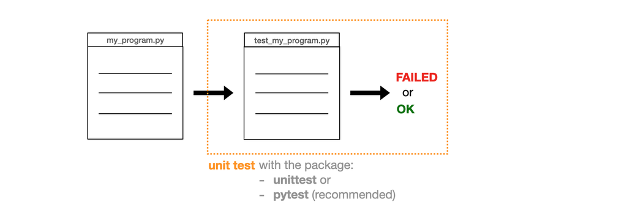

**Example of unit test with unittest :** we want to calculate the area of a circle

```python
import numpy as np

def circle_area(r):
    return np.pi*(r**2)
```

```python
# test the function
message = "Area of the circle of radius r = {radius} is {area}"
for r in [2, -3, 2+5j, True, "radius"]:
    A = circle_area(r)
    print(message.format(radius = r, area = A))
```

```
Area of the circle of radius r = 2 is 12.566370614359172
Area of the circle of radius r = -3 is 28.274333882308138
Area of the circle of radius r = (2+5j) is (-65.97344572538566+62.83185307179586j)
Area of the circle of radius r = True is 3.141592653589793
```

```
---------------------------------------------------------------------------
TypeError                                 Traceback (most recent call last)
/var/folders/55/c2kg8h2d2wnfzx5wnypmt8kr0000gn/T/ipykernel_47557/360307895.py in <module>
      2 message = "Area of the circle of radius r = {radius} is {area}"
      3 for r in [2, -3, 2+5j, True, "radius"]:
----> 4     A = circle_area(r)
      5     print(message.format(radius = r, area = A))

/var/folders/55/c2kg8h2d2wnfzx5wnypmt8kr0000gn/T/ipykernel_47557/4063705862.py in circle_area(r)
      2
      3 def circle_area(r):
----> 4     return np.pi*(r**2)

TypeError: unsupported operand type(s) for ** or pow(): 'str' and 'int'
```

```python
import unittest

class TestCircleArea(unittest.TestCase):
    def test_area(self):
        # test aires lorsque rayon >= 0
        self.assertAlmostEqual(circle_area(1), np.pi)
        self.assertAlmostEqual(circle_area(0), 0)
        self.assertAlmostEqual(circle_area(1.1), pi * 1.1**2)
```

```python
#unittest.main(argv=[''], verbosity=2, exit=False);
! python -m unittest
```

```
.
----------------------------------------------------------------------
Ran 1 test in 0.000s

OK
```

```python
class TestCircleArea(unittest.TestCase):
    def test_area(self):
        # test aires lorsque rayon >= 0
        self.assertAlmostEqual(circle_area(1), np.pi)
        self.assertAlmostEqual(circle_area(0), 0)
        self.assertAlmostEqual(circle_area(1.1), np.pi * 1.1**2)

    def test_values(self):
        # test aires lorsque rayon <0
        self.assertRaises(ValueError, circle_area, -2)

    def test_types(self):
        # test aires lorsque rayon n'est pas un 'int'
        self.assertRaises(ValueError, circle_area, 3+5j)
        self.assertRaises(ValueError, circle_area, True)
        self.assertRaises(ValueError, circle_area, "radius")
```

```python
#unittest.main(argv=[''], verbosity=2, exit=False);
! python -m unittest
```

```
.FF
======================================================================
FAIL: test_types (test_my_program.TestCircleArea)
----------------------------------------------------------------------
Traceback (most recent call last):
  File "/Users/Faugon/Documents/3_enseignements/EPITA/python/lecture 6/test_my_program.py", line 17, in test_types
    self.assertRaises(ValueError, circle_area, 3+5j)
AssertionError: ValueError not raised by circle_area

======================================================================
FAIL: test_values (test_my_program.TestCircleArea)
----------------------------------------------------------------------
Traceback (most recent call last):
  File "/Users/Faugon/Documents/3_enseignements/EPITA/python/lecture 6/test_my_program.py", line 13, in test_values
    self.assertRaises(ValueError, circle_area, -2)
AssertionError: ValueError not raised by circle_area

----------------------------------------------------------------------
Ran 3 tests in 0.001s

FAILED (failures=2)
```

```python
import numpy as np

def circle_area(r):
    if type(r) not in [int, float]:
        raise ValueError("le rayon doit etre un entier positif")
    if r < 0:
        raise ValueError("le rayon ne peut pas etre negatif")
    return(np.pi*(r**2))
```

```python
#unittest.main(argv=[''], verbosity=2, exit=False)
! python -m unittest
```

```
...
----------------------------------------------------------------------
Ran 3 tests in 0.000s

OK
```

**Example of unit test with pytest (recommended) :** we want to calculate the area of a circle

```python
from my_program import *
import numpy as np
import pytest

def test_area():
    # test aires lorsque rayon >= 0
    circle_area(1) == np.pi
    circle_area(0) == 0
    circle_area(1.1) == np.pi * 1.1**2

def test_values():
    # test aires lorsque rayon <0
    with pytest.raises(ValueError):
        circle_area(-2)

def test_types():
    # test aires lorsque rayon n'est pas un 'int'
    with pytest.raises(ValueError):
        circle_area(3+5j)
        circle_area(True)
        circle_area("radius")
```

```python
#unittest.main(argv=[''], verbosity=2, exit=False)
! py.test test_my_program.py
```

```
============================= test session starts ==============================
platform darwin -- Python 3.8.0, pytest-6.2.5, py-1.11.0, pluggy-1.0.0
rootdir: /Users/Faugon/Documents/3_enseignements/EPITA/python/lecture 6
collected 3 items

test_my_program.py ...                                                   [100%]

============================== 3 passed in 0.18s ===============================
```

**OR**

```python
! py.test
```

```
============================= test session starts ==============================
platform darwin -- Python 3.8.0, pytest-6.2.5, py-1.11.0, pluggy-1.0.0
rootdir: /Users/Faugon/Documents/3_enseignements/EPITA/python/lecture 6
collected 3 items

test_my_program.py ...                                                   [100%]

============================== 3 passed in 0.16s ===============================
```

### Unit test coverage

measures the number of lines of code actually executed during the execution of unit tests. (objective approx. 80%. e.g. module coverage to measure the coverage)

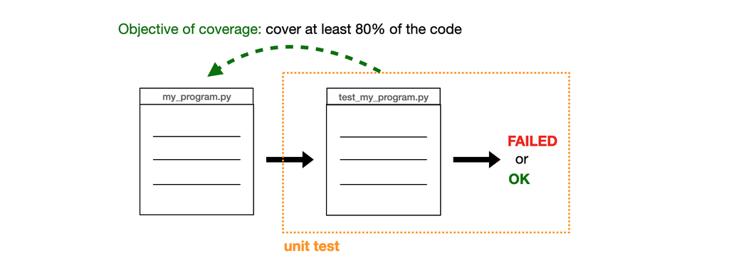

```python
# or "pytest -cov test_my_program.py"
! pytest -cov
```

```
============================= test session starts ==============================
platform darwin -- Python 3.8.0, pytest-6.2.5, py-1.11.0, pluggy-1.0.0
rootdir: /Users/Faugon/Documents/3_enseignements/EPITA/python/lecture 6, configfile: ov
collected 3 items

test_my_program.py ...                                                   [100%]

============================== 3 passed in 0.20s ===============================
```

**OR**

```python
# or "pytest -cov test_my_program.py"
! pytest -report
```

```
============================= test session starts ==============================
platform darwin -- Python 3.8.0, pytest-6.2.5, py-1.11.0, pluggy-1.0.0
rootdir: /Users/Faugon/Documents/3_enseignements/EPITA/python/lecture 6
collected 3 items

test_my_program.py ...                                                   [100%]

=========================== short test summary info ============================
PASSED test_my_program.py::test_area
PASSED test_my_program.py::test_values
PASSED test_my_program.py::test_types
============================== 3 passed in 0.16s ===============================
```

So all in all, here is our **program** and our **test program**:

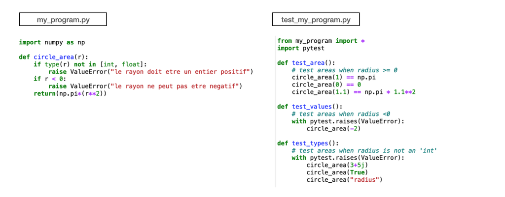

```python
! pytest -cov
```

```
============================= test session starts ==============================
platform darwin -- Python 3.8.0, pytest-6.2.5, py-1.11.0, pluggy-1.0.0
rootdir: /Users/Faugon/Documents/3_enseignements/EPITA/python/lecture 6, configfile: ov
collected 3 items

test_my_program.py ...                                                   [100%]

============================== 3 passed in 0.25s ===============================
```

### Profiling

Allows to measure the execution speed and the consumption of each function or each line. **When is profiling used?** Used when the program is slow and we want to know why.

Naively if we want to quantify the **time complexity** of a function:

```python
# Let us generate 100M of 1 in a container and compare the time complexities

import numpy as np
import time
n = 100000000

# with list and for range
start = time.time()
l = [1 for _ in range(n)]
end = time.time()
print("time needed (in sec): ", round(end-start, 3))

# with list and concatenation
start = time.time()
l = [1]*n
end = time.time()
print("time needed (in sec): ", round(end-start, 3))

# with the method "ones" of numpy
start = time.time()
l = np.ones(n)
end = time.time()
print("time needed (in sec): ", round(end-start, 3))
```

```
time needed (in sec):  5.941
time needed (in sec):  1.657
time needed (in sec):  1.055
```

**Why and how ?**

- In **theoretical computer science**: we would study the [algorithmic complexity](https://devopedia.org/algorithmic-complexity) which measures how long an algorithm would take to complete given an input of size $n$.
- In **practice**: most of the time in a high-level programming such as Python, the external functions might be too complex (or time consuming) to study "theoretically" the *algorithmic complexity*. So instead we focus on **profiling methods** which, given a particular case, scan the entire program and highlight which function (or rows) the program the program loses time.

```
pip install snakeviz
```

```python
%load_ext snakeviz
```

```python
# All methods
import numpy as np

def method1(n):
    return [1 for _ in range(n)]

def method2(n):
    return [1]*n

def method3(n):
    return np.ones(n)

def main_results():
    n = 100000000

    l = []
    for _ in range(n):
        l.append(1)

    l1 = method1(n)
    l2 = method2(n)
    l3 = method3(n)
```

```python
%snakeviz main_results()
```

[figure not shown]

**In a terminal**,

1. print the profiler of the program `my_program_methods.py` (ordered by internal time) with:

   ```
   python -m cProfile -s time my_program_methods.py
   ```

2. you can generate and store the profiler of `my_program_methods.py` into `my_program_methods.prof` with:

   ```
   python -m cProfile -s time -o my_program_methods.prof my_program_methods.py
   ```

   then visualize it in a browser thanks to `snakeviz`:

   ```
   snakeviz my_program_methods.prof
   ```

Your `my_program_methods.py` looks like as follows:

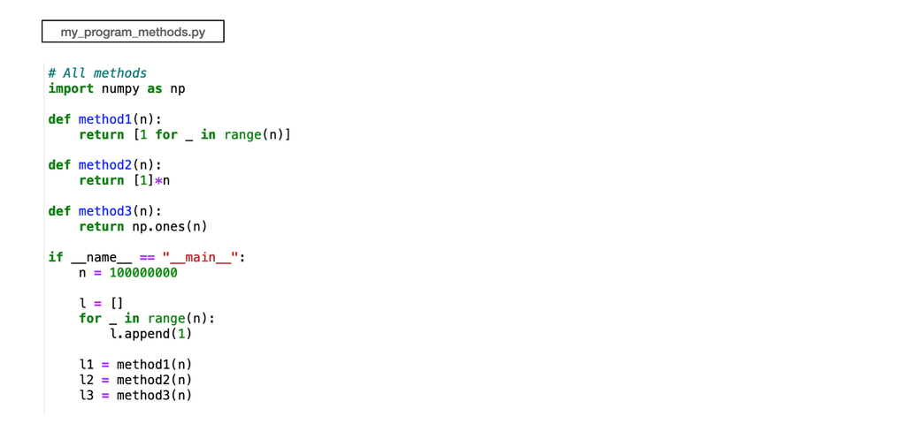

## 2. Code quality

- Logging
- Annotations
- PEP8
- [optional] Documentation with [Sphinx](https://www.sphinx-doc.org/en/master/)

### Logging

[Logging](https://docs.python.org/3/library/logging.html) consists of recording events and operations performed by a program in order to analyze them later (*e.g.* in case of an error).

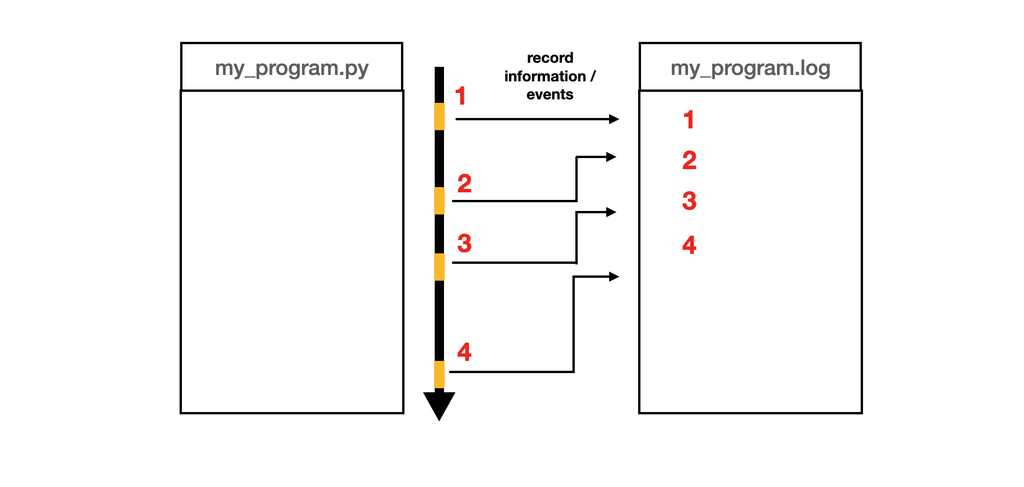

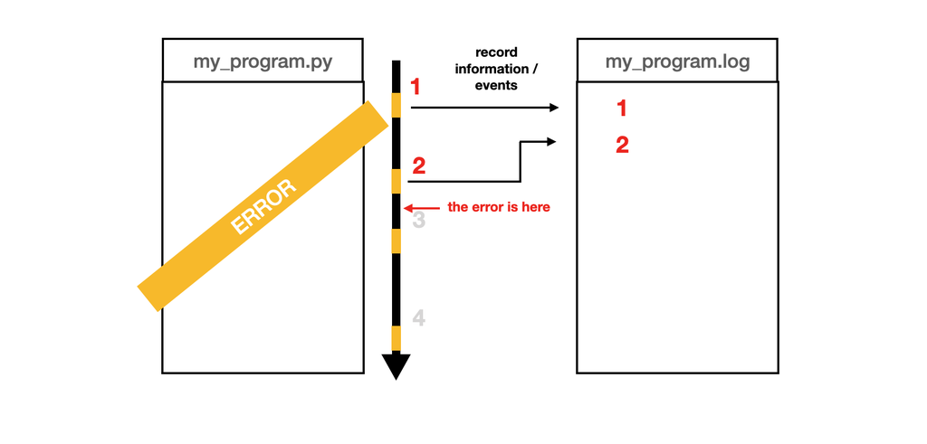

```python
import logging
from math import sqrt

# create and configure our logging
LOG_FORMAT = "%(levelname)s %(asctime)s - %(message)s"
logging.basicConfig(filename = "my_program.log", filemode = "w", level = logging.DEBUG, format = LOG_FORMAT)
logger = logging.getLogger()

# test the logging
def quadratic_formula(a,b,c):
    """Return the solution of the equation ax^2 + bx + c = 0"""
    logger.info("quadratic_formula({0},{1},{2})".format(a,b,c))

    # calculation of the discriminant
    delta = b**2 - 4*a*c

    # calculation of the 2 roots
    logger.debug("# calculation of the 2 roots")
    root1 = (-b + sqrt(delta)) / (2*a)
    root2 = (-b - sqrt(delta)) / (2*a)

    # returns the roots
    logger.debug("# returns the roots")
    return(root1, root2)
```

```python
quadratic_formula(1,0,-4)
```

```
(2.0, -2.0)
```

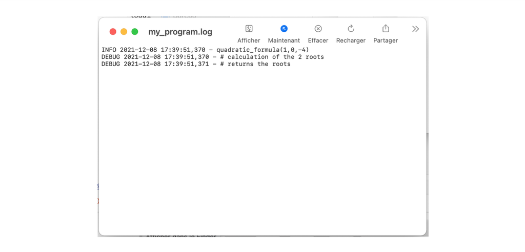

```python
quadratic_formula(1,0,1)
```

```
---------------------------------------------------------------------------
ValueError                                Traceback (most recent call last)
/var/folders/55/c2kg8h2d2wnfzx5wnypmt8kr0000gn/T/ipykernel_28525/3037663929.py in <module>
----> 1 quadratic_formula(1,0,1)

/var/folders/55/c2kg8h2d2wnfzx5wnypmt8kr0000gn/T/ipykernel_28525/3190562289.py in quadratic_formula(a, b, c)
     17     # calculation of the 2 roots
     18     logger.debug("# calculation of the 2 roots")
---> 19     root1 = (-b + sqrt(delta)) / (2*a)
     20     root2 = (-b - sqrt(delta)) / (2*a)
     21

ValueError: math domain error
```

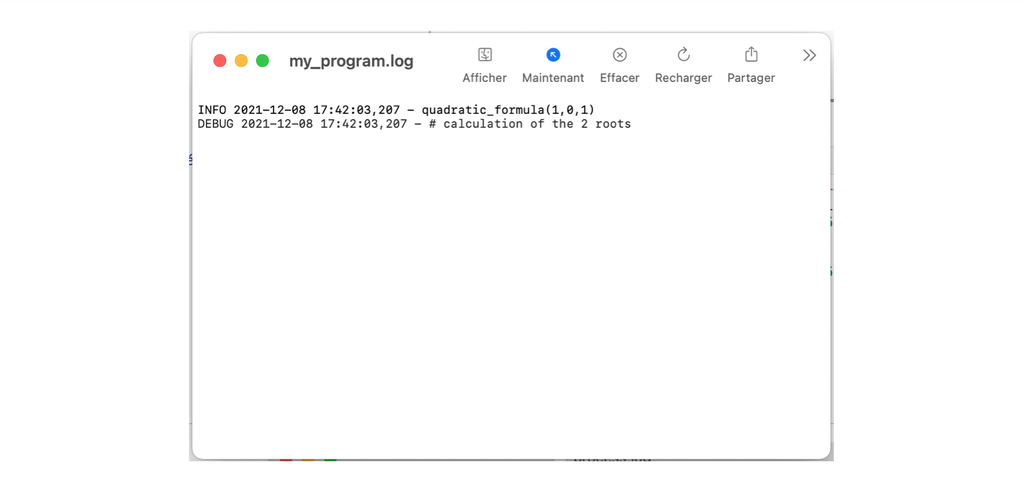

**[Logging](https://docs.python.org/3/library/logging.html) levels:** Debug, Info, **Warning, Error, Critical**

### Annotations

The Python language is weakly typed. Sometimes we specify the expected type in the documentation of a function or a class. Annotations are a formal way to do this. Even if it has no impact, this information can be used

```python
def foo(prefix, suffix):
    """
    prefix: first word
    suffix: last word

    returns : the two words with "and" between
    """
    return prefix + " and " + suffix

foo("eat", "drink")
```

```
'eat and drink'
```

```python
help(foo)
```

```
Help on function foo in module __main__:

foo(prefix, suffix)
    prefix: first word
    suffix: last word

    returns : the two words with "and" between
```

```python
def foo(prefix: str, suffix: str) -> str:
    """
    prefix: first word
    suffix: last word
    returns : the two words with "and" between
    """
    return prefix + " and " + suffix

foo("eat", "drink")
```

```
'eat and drink'
```

```python
help(foo)
```

```
Help on function foo in module __main__:

foo(prefix: str, suffix: str) -> str
    prefix: first word
    suffix: last word
    returns : the two words with "and" between
```

```python
foo.__annotations__
```

```
{'prefix': str, 'suffix': str, 'return': str}
```

### PEP8

It is easier to read a code that always follows the same writing rules. In Python, we call them [PEP8](https://www.python.org/dev/peps/pep-0008/). They are not rules to be followed to the letter but most python developers follow them. Some conventions :

- do **not exceed 79 characters** per line of code ...
- skip **two lines** between functions and classes (but one line between methods of a class)
- **regular_variables**: in lower case with "_" if needed
- **CONSTANTS**: all upper case
- **function_name()**: lowercase with "_" if needed
- **ClassNames**: upper case for each word beginning
- **_non_public_properties**: "_" at the beginning
- **conflictname_**: "_" at the end if there are name conflicts

## 3. [optional] tools and project management

- Source tracking software with [Github](https://github.com/) or [Gitlab](https://gitlab.com/gitlab-org/gitlab)
- Project management with [KanBan](https://www.atlassian.com/fr/agile/kanban)
- Code review with [gerrit](https://www.gerritcodereview.com/)
- Continuous integration with [Jenkins](https://www.jenkins.io/) (locally)